# Anomalous sound detection in industrial pumps

David Ciudad Gómez

23 Master Data Science Madrid

- Introduction
- State of the art
- Project
- Dataset
- Methodology
  - Supervised anomaly detectors
    1. Spectrogram supervised anomaly detector
    2. Mel-spectrogram supervised anomaly detector
  - Semi-supervised anomaly detectors
    1. Spectral centroid semi-supervised anomaly detector
    2. Log-mel spectrogram supervised anomaly detector (Challenge baseline model)
    3. Log-mel spectrogram supervised anomaly detector (MIMMI paper model)
- Summary
- Conclusions
- Lessons learnt
- Appendix
  - MLOps
    - Docker
    - Docker compose
    - Tensorflow serving
  - Streamlit

## Introduction

Anomalous sounds can indicate a fault in a piece of machinery, and early detection of them would prevent the propagation of damage. Because of that, the scientific machine learning community is putting a lot of attention on **anomalous sound detection (ASD)**.

ASD is the task of identifying whether the sound emitted from an object is normal or anomalous.

[figure not shown]

Anomaly detection techniques can be categorized as:.

- **Supervised anomaly detection** requires the entire dataset to be labeled "normal" or "anomaly". This technique is a binary classification task.
- **Semi-supervised anomaly detection** requires only data considered "normal" to be labeled. In this technique, the model will learn what "normal" data are like.
- **Unsupervised anomaly detection** involves unlabeled data. In this technique, the model will learn which data is "normal" and "anomaly".

## State of the art

The three most cited datasets were: [ToyADMOS](https://www.arxiv-vanity.com/papers/1908.03299/), [MIMII](https://www.arxiv-vanity.com/papers/1909.09347/), and [Mivia](https://mivia.unisa.it/datasets/audio-analysis/mivia-audio-events/).

- The **ToyADMOS** dataset is a machine operating sound dataset that has approximately 540 hours of normal sound and approximately 12,000 hours of anomalous sound. ToyADMOS was designed to detect audio anomalies in research involving machine operation.
- The **MIMII** dataset is a data set for investigation and inspection of defective industrial machines. It contains the sounds generated from four types of industrial machines (valves, pumps, fans and slide rails).
- The **Mivia** dataset is an audio dataset composed of 6,000 events considered to be vigilance (glass break, shots and screams).

```
OWN DATASET      10
MIMII             8
TOYADMOS          8
MIVIA DATASET     4
TUT DATASET       4
Name: value, dtype: int64
```

The main methods of extracting features were: [Mel-frequency cepstral coefficients (MFCCs)](https://en.wikipedia.org/wiki/Mel-frequency_cepstrum), Log-Mel Energy, and Mel-spectrogram.

```
MFCC                10
LOG-MEL ENERGIES     7
MEL-SPECTROGRAM      5
ZCR                  4
DWT                  3
Name: value, dtype: int64
```

```
AE               7
ONE-CLASS SVM    5
CNN              4
CAE              4
WAVENET          3
Name: value, dtype: int64
```

The most used metrics were:

- **AUC-ROC** is a performance evaluation that involves classification problems with thresholds. AUC represents a degree of separability and ROC is a probability curve. The higher the AUC, the better the model for predicting a particular class.
- **F1-score** measures the accuracy of an ML model. It is widely used in classification.

```
ROC-AUC     19
F1-SCORE    12
ACCURACY     6
ROC-PAUC     5
ER           5
Name: value, dtype: int64
```

## Project

This project is my attempt to solve the task [Unsupervised Detection of Anomalous Sounds for Machine Condition Monitoring](http://dcase.community/challenge2020/task-unsupervised-detection-of-anomalous-sounds) from the [2020 DCASE Challenge](http://dcase.community/challenge2020/) for pumps.

It consists of two steps:

1. **develop** machine learning algorithms to distinguish anomalous sound from normal sounds in Jupyter notebooks using Tensorflow
2. put in **production** the best model in a Streamlit web app with Tensorflow serving

My goals for this projects are:

1. Experiment with different audio features (spectrogram, mel-spectrogram, log mel-spectrogram...)
2. Replicate the MIMMI paper model and 2020 DCASE challenge baseline model
3. Find a model that improves the metrics of those models.
4. Experiment with MLOps best practices

## Dataset

The dataset of this project is the [development dataset](https://zenodo.org/record/3678171) of pumps from the second task of the [2020 DCASE Challenge](http://dcase.community/challenge2020/task-unsupervised-detection-of-anomalous-sounds), a simplified version of the [MIMII](https://www.arxiv-vanity.com/papers/1909.09347/) dataset (audio files have only one channel instead of eight channels).

The dataset contains 3349 audio files for training and 856 audio files for testing. Each recording is a single-channel 10-sec length audio that includes both a target machine's operating sound and environmental noise.

To speed up the training and manipulation of the audio samples, I have transformed the [development dataset](https://zenodo.org/record/3678171) of pumps from the second task of the [2020 DCASE Challenge](http://dcase.community/challenge2020/task-unsupervised-detection-of-anomalous-sounds) into a [Tensorflow dataset](https://www.tensorflow.org/datasets/overview). The original dataset of pumps has two folders (train and test) and filenames explain whether the audio sample is normal or anomaly and which machine it belongs to.

My Tensorflow dataset has the following information:

- **audio** holds the values of the audio file. Audios last 10 seconds and were recorded at 16kHz with a resolution of 16 bits
- **audio/id** is the id number of the audio
- **audio/machine** is the number of the pump (00, 02, 04, 06)
- **audio/split** shows the folders where the file comes from (train or test)
- **label** shows whether the sound is normal or anomaly

```
FeaturesDict({
    'audio': Audio(shape=(160000,), dtype=tf.int64),
    'audio/id': Text(shape=(), dtype=tf.string),
    'audio/machine': Text(shape=(), dtype=tf.string),
    'audio/split': ClassLabel(shape=(), dtype=tf.int64, num_classes=2),
    'label': ClassLabel(shape=(), dtype=tf.int64, num_classes=2),
})
```

To have a better understanding of the audio samples, we can listen to anomaly and normal audios and see some of the their main audio features (waveplots, spectograms and mel-spectrograms).

|  | audio | audio/id | audio/machine | audio/split | label |
| --- | --- | --- | --- | --- | --- |
| 0 |  | 0333 | 02 | 0 (train) | 0 (normal) |

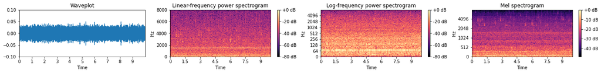

|  | audio | audio/id | audio/machine | audio/split | label |
| --- | --- | --- | --- | --- | --- |
| 0 |  | 0090 | 00 | 1 (test) | 0 (normal) |

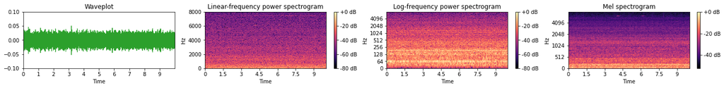

|  | audio | audio/id | audio/machine | audio/split | label |
| --- | --- | --- | --- | --- | --- |
| 0 |  | 0036 | 02 | 1 (test) | 1 (anomaly) |

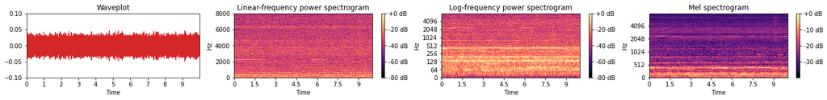

This pivot table shows the number of audios per split (train/test), machine_id (00,02,04,06) and label (normal/anomaly).

| split label machine_id | test anomaly | test normal | train normal |
| --- | --- | --- | --- |
| 00 | 143 | 100 | 906 |
| 02 | 111 | 100 | 905 |
| 04 | 100 | 100 | 602 |
| 06 | 102 | 100 | 936 |

Although by design, this dataset is more suitable for **semi-supervised anomaly detection**, this dataset can be used for **supervised anomaly detection** using only audios from the test split.

So, I need to check whether there is enough data and whether the new train/validation/test splits are balanced enough for supervised anomaly detection.

**Train** split:

| label audio/machine | normal | anomaly |
| --- | --- | --- |
| 00 | 74 | 96 |
| 02 | 62 | 83 |
| 04 | 74 | 70 |
| 06 | 72 | 68 |

**Validation** split:

| label audio/machine | normal | anomaly |
| --- | --- | --- |
| 00 | 20 | 30 |
| 02 | 22 | 20 |
| 04 | 16 | 18 |
| 06 | 20 | 25 |

**Test** split:

| label audio/machine | normal | anomaly |
| --- | --- | --- |
| 00 | 6 | 17 |
| 02 | 16 | 8 |
| 04 | 10 | 12 |
| 06 | 8 | 9 |

Although I would like to have more audios to get a more robust model, I think I have enough data a supervised anomaly detector.

## Methodology

I have created the following anomaly detectors:

- Supervised anomaly detectors
  1. Spectrogram supervised anomaly detector
  2. Mel-spectrogram supervised anomaly detector
- Semi-supervised anomaly detectors
  1. Spectral centroid semi-supervised anomaly detector
  2. Log-mel spectrogram supervised anomaly detector (Challenge baseline model)
  3. Log-mel spectrogram supervised anomaly detector (MIMMI paper model)

### Supervised anomaly detector

For the supervised anomaly detectors, I use the [convolutional neural network (CNN)](https://en.wikipedia.org/wiki/Convolutional_neural_network) architecture.

[figure not shown]

Instead of extracting the audio feature (spectrogram or Mel-spectrogram) to use it as the input for the CNN, I use a custom Keras layer that extracts the audio feature. Using custom Keras layers has two main advantages:

- the input to the model is the audio itself so the Streamlit web app doesn't need to manipulate it to feed the model
- the custom layer is compatible with AutoKeras

#### Spectragram supervised anomaly detector

This is a model uses the [spectrogram](https://en.wikipedia.org/wiki/Spectrogram) as audio feature.

```
Model: "sequential"
_________________________________________________________________
Layer (type)                 Output Shape              Param #
=================================================================
reshape (Reshape)            (None, 160000, 1)         0
_________________________________________________________________
stft_magnitude (Sequential)  (None, 311, 513, 1)       0
_________________________________________________________________
batch_normalization (BatchNo (None, 311, 513, 1)       4
_________________________________________________________________
conv2d (Conv2D)              (None, 311, 513, 8)       80
_________________________________________________________________
max_pooling2d (MaxPooling2D) (None, 103, 171, 8)       0
_________________________________________________________________
batch_normalization_1 (Batch (None, 103, 171, 8)       32
_________________________________________________________________
conv2d_1 (Conv2D)            (None, 103, 171, 16)      1168
_________________________________________________________________
max_pooling2d_1 (MaxPooling2 (None, 51, 57, 16)        0
_________________________________________________________________
batch_normalization_2 (Batch (None, 51, 57, 16)        64
_________________________________________________________________
conv2d_2 (Conv2D)            (None, 51, 57, 32)        4640
_________________________________________________________________
max_pooling2d_2 (MaxPooling2 (None, 25, 19, 32)        0
_________________________________________________________________
batch_normalization_3 (Batch (None, 25, 19, 32)        128
_________________________________________________________________
flatten (Flatten)            (None, 15200)             0
_________________________________________________________________
dense (Dense)                (None, 64)                972864
_________________________________________________________________
dropout (Dropout)            (None, 64)                0
_________________________________________________________________
dense_1 (Dense)              (None, 16)                1040
_________________________________________________________________
dropout_1 (Dropout)          (None, 16)                0
_________________________________________________________________
dense_2 (Dense)              (None, 1)                 17
=================================================================
Total params: 980,037
Trainable params: 979,923
Non-trainable params: 114
_________________________________________________________________
```

#### Mel-spectrogram supervised anomaly detector

This model uses the Mel-spectrogram as the audio feature.

```
Model: "sequential_1"
_________________________________________________________________
Layer (type)                 Output Shape              Param #
=================================================================
reshape_1 (Reshape)          (None, 160000, 1)         0
_________________________________________________________________
melspectrogram (Sequential)  (None, 311, 128, 1)       0
_________________________________________________________________
batch_normalization_4 (Batch (None, 311, 128, 1)       4
_________________________________________________________________
conv2d_3 (Conv2D)            (None, 311, 128, 8)       80
_________________________________________________________________
max_pooling2d_3 (MaxPooling2 (None, 103, 64, 8)        0
_________________________________________________________________
batch_normalization_5 (Batch (None, 103, 64, 8)        32
_________________________________________________________________
conv2d_4 (Conv2D)            (None, 103, 64, 16)       1168
_________________________________________________________________
max_pooling2d_4 (MaxPooling2 (None, 34, 32, 16)        0
_________________________________________________________________
batch_normalization_6 (Batch (None, 34, 32, 16)        64
_________________________________________________________________
conv2d_5 (Conv2D)            (None, 34, 32, 32)        4640
_________________________________________________________________
max_pooling2d_5 (MaxPooling2 (None, 17, 16, 32)        0
_________________________________________________________________
batch_normalization_7 (Batch (None, 17, 16, 32)        128
_________________________________________________________________
flatten_1 (Flatten)          (None, 8704)              0
_________________________________________________________________
dense_3 (Dense)              (None, 64)                557120
_________________________________________________________________
dropout_2 (Dropout)          (None, 64)                0
_________________________________________________________________
dense_4 (Dense)              (None, 8)                 520
_________________________________________________________________
dropout_3 (Dropout)          (None, 8)                 0
_________________________________________________________________
dense_5 (Dense)              (None, 1)                 9
=================================================================
Total params: 563,765
Trainable params: 563,651
Non-trainable params: 114
_________________________________________________________________
```

### Semi-supervised anomaly detector

For the semi-supervised anomaly detectors, I use the architecture [autoencoder (AE)](https://en.wikipedia.org/wiki/Autoencoder), a popular approach for this kind of problems, as the paper [Anomalous Sound Detection with Machine Learning: A Systematic Review](https://www.arxiv-vanity.com/papers/2102.07820/) shows.

The main characteristicts of an **autoencoder** are:

- The output layer has the same number of nodes as the input layer.
- The middle layer has much less nodes than the input.

[figure not shown]

Source: [An Introduction to Neural Networks and Autoencoders](https://www.alanzucconi.com/2018/03/14/an-introduction-to-autoencoders/)

The purpose of an autoencoder is to reconstruct its inputs minimizing the difference between the input and the output, the **reconstruction error**.

The anomaly detector will learn how normal sounds look like and give smaller reconstruction error for normal sounds than for anomaly sounds.

[figure not shown]

Source: [AWS](https://aws.amazon.com/es/blogs/machine-learning/performing-anomaly-detection-on-industrial-equipment-using-audio-signals/)

The anomaly detector distinguishes anomalous sounds from normal sounds based on a threshold.

$$ f(x) = \begin{cases} 1, \text{ normal if } x \lt threhold \\ 0, \text{ anomaly if } x \geq threshold \end{cases} $$

I set the threshold value to be one standard deviation above the mean of the reconstruction error in the training set.

The differences between the three models are:

- the audio feature that the model uses as input and output
- the internal layers of the neural network

#### Spectral centroid semi-supervised anomaly detector

This model uses the [spectral centroid](https://en.wikipedia.org/wiki/Spectral_centroid) of the audios as the input. It is calculated as the weighted mean of the frequencies present in the signal, determined using a Fourier transform, with their magnitudes as the weights

[figure not shown]

This audio feature is not very popular as the paper [Anomalous Sound Detection with Machine Learning: A Systematic Review](https://www.arxiv-vanity.com/papers/2102.07820/) shows, but it is one of the few 1D audio features that I can use.

[output not shown]

#### Log-mel spectrogram supervised anomaly detector (Challenge baseline model)

This is the model described in the [2020 DCASE Challenge](http://dcase.community/challenge2020/task-unsupervised-detection-of-anomalous-sounds) as the baseline model. It uses a modified version of the log Mel-spectrogram as the input.

Mel-spectrogram and log Mel-spectrogram are popular audio features for machine learning models.

[output not shown]

#### Log-mel spectrogram supervised anomaly detector (MIMII paper model)

This is the model described in the paper [MIMII Dataset: Sound Dataset for Malfunctioning Industrial Machine Investigation and Inspection](https://www.arxiv-vanity.com/papers/1909.09347/). It uses a modified version of the log Mel-spectrogram as the input.

Mel-spectrogram and log Mel-spectrogram are popular audio features for machine learning models.

[output not shown]

## Summary

Summary table for supervised anomaly detectors:

| feature machine | Mel-spectrogram | spectrogram |
| --- | --- | --- |
| 00 | 0.8235 | 0.6569 |
| 02 | 0.9375 | 0.9688 |
| 04 | 0.8333 | 0.8750 |
| 06 | 0.7708 | 0.8333 |

Summary table for semi-supervised anomaly detectors:

| feature machine | log Mel-spectrogram (Challenge) | log Mel-spectrogram (MIMII) | spectral centroid |
| --- | --- | --- | --- |
| 00 | 0.5209 | 0.5473 | 0.4805 |
| 02 | 0.5131 | 0.5266 | 0.4936 |
| 04 | 0.5150 | 0.4850 | 0.4850 |
| 06 | 0.5176 | 0.4928 | 0.4934 |

## Conclusions

1. The copycat models perform much worse than the models described in the MIMII paper and the 2020 DCASE Challenge. It seems Tensorflow calculates the STFT different than the librosa does.
2. Supervised anomaly detectors perform much better than semi-supervised ones and the performance doesn't change significantly when the model uses another audio feature.
3. Supervised models don't perform homogenously among all machines, so the machine_id could be an important feature to improve the performance of the models. To add the machine_id, I would choose:
   - two-step training: firstly, train a general model with data of the four models, and later get four models through fine-tuning with data of each machine.
   - use the machine_id as input in the neural networks

## Lessons learnt

1. Tensorflow datasets are very convenient to create pipelines and speed up training. However, third-party libraries manipulation and debugging are much harder because Tensorflow datasets use graph execution mode. According to Tensorflow API documentation of map function, "irrespective of the context in which map_func is defined (eager vs. graph), tf.data traces the function and executes it as a graph."
2. Replicate the 2020 DCASE Challenge baseline model and the MIMII paper model were impossible because Tensorflow functions for signal manipulation are less developed than Pytorch/torchaudio and Librosa. In hindsight, replicate those models would have been easier with Pytorch or Torchlibrosa.
3. Train a semi-supervised anomaly detector is much more difficult than train a supervised anomaly detector because common guidelines for supervised machine learning don't apply to semi-supervised machine learning.
4. Docker containers and Docker compose simplify and ensure the replicability of my code.

## Appendix

### MLOps

Among all the tools to ensure the reproducibility of my code and the track my dataset and models, I have decided to use *Docker*, *Docker compose* and *Tensorflow Serving*. The Tensorflow dataset that I created helps me to do version control of the data.

I have experimented with [CML](https://cml.dev/)/[Github Actions](https://docs.github.com/en/actions) and [MLflow](https://mlflow.org/), but. I have decided not to use because:

- CML or Github Actions seems to be more suitable for smaller datasets and training times
- it is easier to serve a Tensorflow model with Tensorflow Serving that with MLflow.

#### Docker

To ensure the reproducibility of my code, I use four Docker images:

- **development_tensorboad**: the image for Tensorboard. The Dockrefile installs Tensorboard package in a 3.8 Python Docker image.
- **development_notebook**: the image for the Jupyter notebooks. The Dockerfile installs the required packages in a 3.7 Python Docker image.
- **production_frontend**: the image for the Streamlit app. The Dockerfile installs Streamlit package in a 3.8 Python Docker image.
- **tensorflow/serving**: a Tensorflow serving Docker image from Docker hub.

[figure not shown]

The Docker image for the Jupyter notebooks is different from the Docker image for Tensorboard and Streamlit because the wordcloud package wheel is not available for Python 3.8.

#### Docker compose

I use Docker compose to run the required containers for production and development environment:

- **Development** Docker compose file runs the Docker container for the Jupyter notebooks and Tensorboard server and mounts several volumes for the notebooks.
- **Production** Docker compose file runs the Docker image for the Streamlit web app and Tensorflow serving, creates a network to connect them and mounts several volumes for the source code of the app and the Tensorflow models for the Tensorflow serving.

#### Tensorflow Serving

Tensorflow Serving as a backend for the Streamlit helps me:

- to reduce the size of the Streamlit image because it doesn't need Tensorflow to make predictions
- to track the models in production because Tensorflow Serving uses the model that has the higher version

Tensorflow Serving knows the name and the files of the models from the *models.config* file. To add a new model, I need to declare it in the models.config file and mount a new volume in the Docker compose file.

### Streamlit

I have designed the Streamlit web app as a four-step game. So, users can test themselves and compare their guesses against my trained models' predictions.

In the **first step**, the user can choose a trained model. Between the five models that I have trained, the user can only choose the supervised anomaly detectors because any of the three semi-supervised anomaly detectors work very poor.

In the **second step**, the user can select an audio file to guess whether its sound is normal or anomalous. To make it easier, the user can train themselves with normal audios from the same machine. The user can listen to the audio and inspect its wave plot, spectrogram and Mel-spectrogram.

In the **third step**, the user can pick whether the sound is normal or anomalous.

In the **last step**, the user can check the true label of the audio label and compare his guess against the chosen model's predictions. The user can also check how sure the model is with its prediction.